# PML Assignment

David Short

16 July 2016

## Introduction

The task for this assignment is to create a model capable of predicting whether a person is using a piece of exercise equipment correctly, based on data recorded by sensors worn on the body. In this case the exercise equipment was a dumbbell used to perform a biceps curl, with sensors located on the belt, upper arm, forearm and on the dumbbell itself.

The data used relates to the paper“Qualitative Activity Recognition of Weight Lifting Exercises” by Velloso, E.; Bulling, A.; Gellersen, H.; Ugulino, W.; Fuks, H.

More information about this paper can be found at http://groupware.les.inf.puc-rio.br/har#ixzz4EcRDpAYb.

## Data Download

The training data set was downloaded from https://d396qusza40orc.cloudfront.net/predmachlearn/pml-training.csv.

A testing data set was also downloaded from https://d396qusza40orc.cloudfront.net/predmachlearn/pml-testing.csv.

## Library

The caret library is used to model data within this assignment. The rattle library is used to show the decision tree model.

```r
library(caret)
library(rattle)
```

## Data Selection

Exploratory analysis revealed not all columns within the data set were fully populated, with large numbers of NA and !DIV/0 values. As these sparsely populated columns would produce an unreliable model, these were excluded.

Also excluded were columns that did not appear to be likely to influence the prediction, such as participant and date/time information.

This left us with 52 measurement columns, along with the classe column to be predicted.

The classe column has 5 possible values:

- A - exercise performed correctly;
- B - elbows thrown to the front;
- C - dumbbell lifted only halfway;
- D - dumbbell lowered only halfway; and
- E - hips thrown to the front.

The data was segmented into a training set (70%) and a testing set (30%) for model development.

```r
setwd("~/R/PML Assignment")
trainingFull <- read.csv("pml-training.csv",stringsAsFactors = FALSE)
trainingFull$classe <- as.factor(trainingFull$classe)

beltCols <- c("roll_belt","pitch_belt","yaw_belt","total_accel_belt","gyros_belt_x","gyros_belt_y","gyros_belt_z","accel_belt_x","accel_belt_y","accel_belt_z","magnet_belt_x","magnet_belt_y","magnet_belt_z")

armCols <- c("roll_arm","pitch_arm","yaw_arm","total_accel_arm","gyros_arm_x","gyros_arm_y","gyros_arm_z","accel_arm_x","accel_arm_y","accel_arm_z","magnet_arm_x","magnet_arm_y","magnet_arm_z")

dumbbellCols <- c("roll_dumbbell","pitch_dumbbell","yaw_dumbbell","total_accel_dumbbell","gyros_dumbbell_x","gyros_dumbbell_y","gyros_dumbbell_z","accel_dumbbell_x","accel_dumbbell_y","accel_dumbbell_z","magnet_dumbbell_x","magnet_dumbbell_y","magnet_dumbbell_z")

forearmCols <- c("roll_forearm","pitch_forearm","yaw_forearm","total_accel_forearm","gyros_forearm_x","gyros_forearm_y","gyros_forearm_z","accel_forearm_x","accel_forearm_y","accel_forearm_z","magnet_forearm_x","magnet_forearm_y","magnet_forearm_z")

colsToInclude <- c("classe",beltCols,armCols,dumbbellCols,forearmCols)

trainingSubset <- trainingFull[colsToInclude]

set.seed(710)
inTrain <- createDataPartition(trainingSubset$classe,p=0.7,list=FALSE)
trainingSet <- trainingSubset[inTrain,]
testingSet <- trainingSubset[-inTrain,]
```

## Fitting Models

### Decision Tree

A decision tree model was fitted to the data.

```r
set.seed(1812)
treeFit <- train(classe~., data=trainingSet, method="rpart")
```

```r
treePred <- predict(treeFit, newdata=testingSet)
treeMatrix <- confusionMatrix(testingSet$classe, treePred)

treeMatrix$table
```

```
##           Reference
## Prediction    A    B    C    D    E
##          A 1501   24  124    0   25
##          B  450  384  305    0    0
##          C  467   41  518    0    0
##          D  437  165  362    0    0
##          E  162  142  281    0  497
```

```r
treeMatrix$overall[1]
```

```
##  Accuracy
## 0.4927782
```

```r
treeAccuracyPercent <- sprintf("%2.2f",treeMatrix$overall[1]*100)
```

This indicated an accuracy of 49.28%. This indicates that the model is not particularly useful for predicting the correct conduct of this exercise.

### Random Forest

A random forest model was then fitted to the data. Cross validation method was used as somewhat more efficient than resampling.

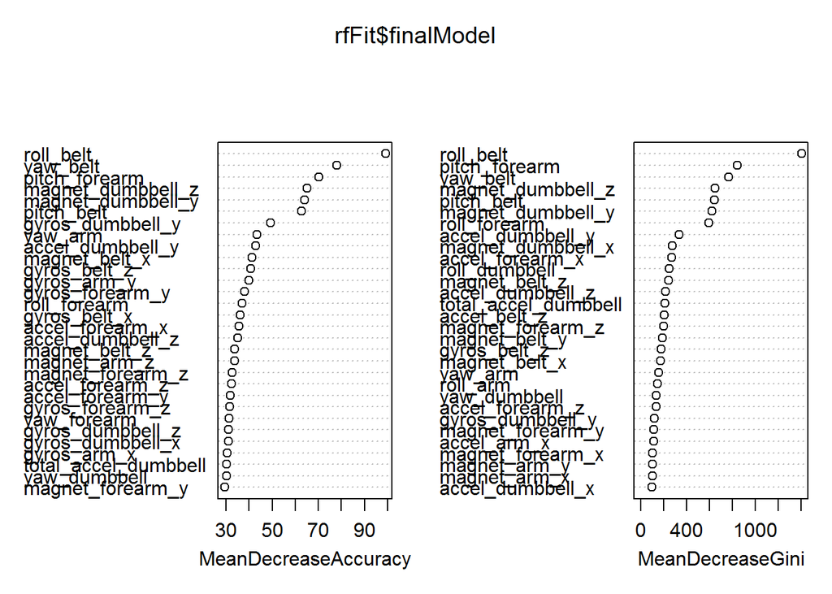

```r
set.seed(1602)
rfFitControl <- trainControl(method="cv",number=10)
rfFit <- train(classe~.,data=trainingSet,model="rf",trControl=rfFitControl, importance=TRUE)

varImpPlot(rfFit$finalModel)
```

```r
rfPred <- predict(rfFit, newdata = testingSet)
rfMatrix <- confusionMatrix(testingSet$classe, rfPred)

rfMatrix$table
```

```
##           Reference
## Prediction    A    B    C    D    E
##          A 1669    3    1    0    1
##          B   12 1126    1    0    0
##          C    0    5 1020    1    0
##          D    0    0    9  955    0
##          E    0    1    1    5 1075
```

```r
rfMatrix$overall[1]
```

```
##  Accuracy
## 0.9932031
```

```r
rfAccuracyPercent <- sprintf("%2.2f",rfMatrix$overall[1]*100)
```

This indicated an accuracy of 99.32%. This therefore appears to be a good model in predicting incorrect use of the dumbbell in this exercise.

We therefore utilised this model to supply the answers for the prediction quiz data.

```r
testingFull <- read.csv("pml-testing.csv",stringsAsFactors = FALSE)
finalPred <- predict(rfFit, newdata = testingFull)
finalPred <- data.frame(finalPred)
finalPred
```

```
##    finalPred
## 1          B
## 2          A
## 3          B
## 4          A
## 5          A
## 6          E
## 7          D
## 8          B
## 9          A
## 10         A
## 11         B
## 12         C
## 13         B
## 14         A
## 15         E
## 16         E
## 17         A
## 18         B
## 19         B
## 20         B
```

## Conclustion

The random Forest model appears to provide an accurate model that could be used to predict whether this exercise has been performed correctly, and if not, which error has occurred.